# Unit 1 Homework

### W203 Statistics for Data Science

Student Name: Kevin Hartman

Section Number: 4

### Exercises

**1.0:** Load the dataset found in the file, cars.csv.

```r
Cars = read.csv("cars.csv")
```

**2.0:** What are the variables in the file?

```r
head(Cars)
str(Cars)
```

| mpg | cyl | disp | hp | drat | wt | qsec | vs | am | gear | carb |
| --- | --- | --- | --- | --- | --- | --- | --- | --- | --- | --- |
| 21.0 | 6 | 160 | 110 | 3.90 | 2.620 | 16.46 | 0 | 1 | 4 | 4 |
| 21.0 | 6 | 160 | 110 | 3.90 | 2.875 | 17.02 | 0 | 1 | 4 | 4 |
| 22.8 | 4 | 108 | 93 | 3.85 | 2.320 | 18.61 | 1 | 1 | 4 | 1 |
| 21.4 | 6 | 258 | 110 | 3.08 | 3.215 | 19.44 | 1 | 0 | 3 | 1 |
| 18.7 | 8 | 360 | 175 | 3.15 | 3.440 | 17.02 | 0 | 0 | 3 | 2 |
| 18.1 | 6 | 225 | 105 | 2.76 | 3.460 | 20.22 | 1 | 0 | 3 | 1 |

```
'data.frame':	25 obs. of  11 variables:
 $ mpg : num  21 21 22.8 21.4 18.7 18.1 14.3 24.4 22.8 19.2 ...
 $ cyl : int  6 6 4 6 8 6 8 4 4 6 ...
 $ disp: num  160 160 108 258 360 ...
 $ hp  : int  110 110 93 110 175 105 245 62 95 123 ...
 $ drat: num  3.9 3.9 3.85 3.08 3.15 2.76 3.21 3.69 3.92 3.92 ...
 $ wt  : num  2.62 2.88 2.32 3.21 3.44 ...
 $ qsec: num  16.5 17 18.6 19.4 17 ...
 $ vs  : int  0 0 1 1 0 1 0 1 1 1 ...
 $ am  : int  1 1 1 0 0 0 0 0 0 0 ...
 $ gear: int  4 4 4 3 3 3 3 4 4 4 ...
 $ carb: int  4 4 1 1 2 1 4 2 2 4 ...
```

**3.0** Find the mean, median, minimum, maximum, 1st quartile and 3rd quartile for the mpg variable.

```r
summary(Cars$mpg)
```

```
   Min. 1st Qu.  Median    Mean 3rd Qu.    Max.
  10.40   15.20   18.70   19.49   21.50   33.90
```

**4.0:** Create a histogram of the mpg variable.

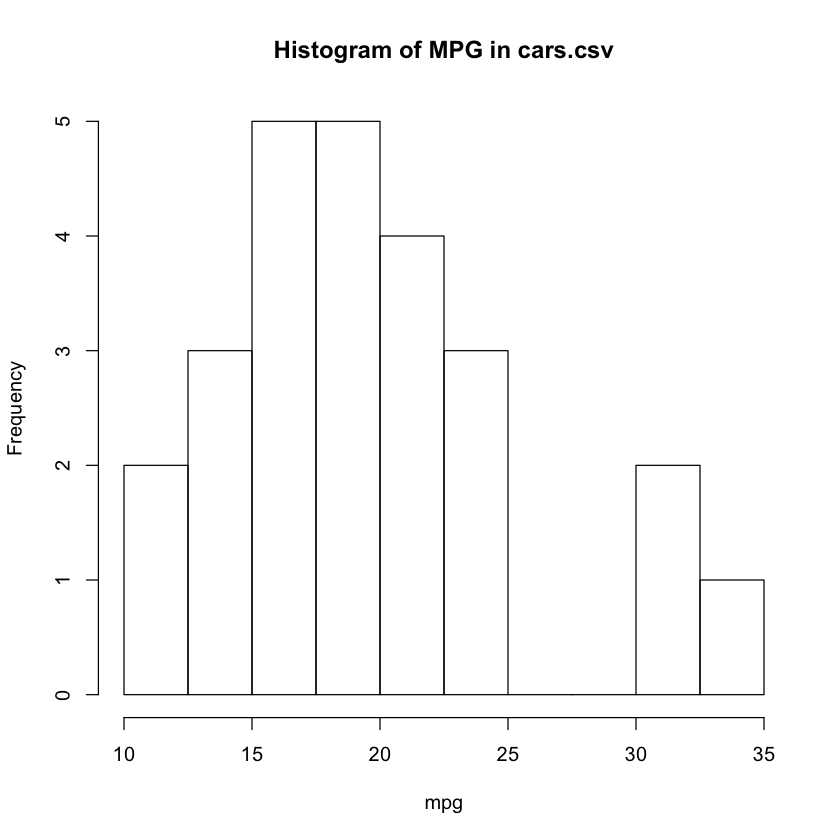

```r
hist(Cars$mpg, main = "Histogram of MPG in cars.csv", xlab = "mpg", breaks = seq(10, 35, by=2.5))
```

**5.0:** What is the standard deviation of mpg variable?

```r
sd(Cars$mpg)
```

6.04744574179876

**6.0:** What is the variance of mpg variable?

```r
var(Cars$mpg)
```

36.5716

**7.0:** What is the relationship of the standard deviation to the variance? Why does the standard deviation and variance of the mpg variable differ?

```r
sd(Cars$mpg) == sqrt(var(Cars$mpg))
```

TRUE

**What is the relationship?**

The standard deviation, $s$, is the square root of the variance, $s^2$.

$s = \sqrt{s^2}$

**Why are they different?**

The variance, $s^2$, is the average squared differences from the mean in a given sample set. Because of the squaring, variance is no longer in the original units of the sample.

We use the square root of variance to get a standard deviation back in our original units. This method of computing standard deviation is used so we can avoid the affects of summing up positive and negative number differences (which would produce a 0).

The variance, $s^2$, is more precisely expressed in the formula below:

$s^2=\frac{S_{xx}}{n-1}=\frac{\sum_{i=1}^n(x_i-\bar{x})^2}{n-1}$

Where $S_{xx}$ is the sum of squares for each deviation from the mean, and ${n-1}$ is the sample size minus 1.

**8.0** How many data points are there for the cyl variable?

```r
length(Cars$cyl[!is.na(Cars$cyl)])
```

23

**9.0** What is the mean of the cyl variable?

```r
mean(Cars$cyl[!is.na(Cars$cyl)])
```

6.26086956521739